Zum Hauptinhalt springen

# 202 datenvis-moderndive-boxplot1

Schlüsselwörter

Aufgaben, Statistik, Prognose, Modellierung, R, Datenanalyse, Regression

Laden Sie das Paket `gapminder` (ggf. vorab installieren) und laden Sie daraus den Datensatz `gapminder`. [Hier](https://www.gapminder.org/) finden Sie weitere Informationen zum Projekt *Gapminder*.

*Tipp*: Mit `help(gapminder)` bekommen Sie mehr Informationen zum Datensatz.

1. Erstellen Sie einen Boxplort für jedes *Land* im Datensatz, um die Verteilung der Lebenserwartung zu visualisieren.
2. Erstellen Sie einen Boxplort für jedes *Kontinent* im Datensatz, um die Verteilung der Lebenserwartung zu visualisieren.
3. Erstellen Sie einen Boxplort für jedes *Kontinent* im Datensatz, um die Verteilung der Lebenserwartung zu visualisieren. Dieses Mal sollen Sie aber vorab den Datensatz zusammenfassen, so dass ein (zeilen-)reduzierter Datensatz entsteht, der für jeden Kontinent eine Zeile umfasst. Wie sinnvoll ist dieses Vorgehen?
4. Erstellen Sie einen Boxplot pro Kontinent und weisen Sie der Füllfarbe die Variable zum Kontinent zu.
5. Erläutern Sie einige Aspekte, die wir aus der letzten Visualisierung lernen zu den Verteilungen.

*Hinweis*: Beziehen Sie sich auf den Stoff dieses Buches: Ismay, C., & Kim, A. (2019). *ModernDive—An Introduction to Statistical and Data Sciences via R*. http://moderndive.com/.

```
library(gapminder)  # falls noch nicht geladen
library(tidyverse)  # falls noch nicht geladen
data("gapminder")  # falls noch nicht geladen

gapminder %>%
  ggplot() +
  aes(x = country, y = lifeExp) +
  geom_boxplot()
```

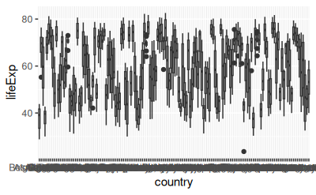

```
gapminder %>%
  ggplot() +
  aes(x = continent, y = lifeExp) +
  geom_boxplot()
```

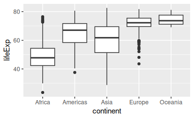

```
gapminder %>%
  group_by(continent) %>%
  summarise(lifeExp_continent = median(lifeExp)) %>%
  ggplot() +
  aes(x = continent, y = lifeExp_continent) +
  geom_boxplot()
```

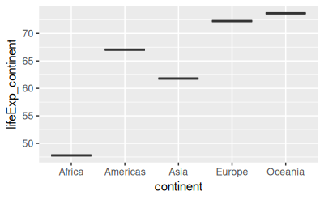

```
gapminder %>%
  ggplot() +
  aes(x = continent, y = lifeExp, fill = continent) +
  geom_boxplot()
```

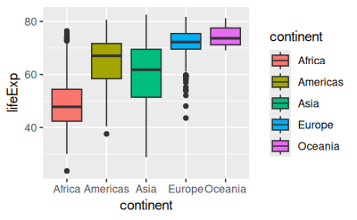

- Die Verteilungen unterscheiden sich in zentraler Tendenz und Variabilität.
- Die Verteilungen sind schief.
- Asien weist die größte Variabilität (in der Lebenswertung) auf.
- In Europa gibt es eine Reihe Extremwerte (gemessen an den übrigen Werten in Europa).
- Ozeanien hat den höchsten medianen Wert in der Lebenserwartung.
- Ozeanien weist die geringste Streuung auf.

Aufgabenname: `datenvis-moderndive-boxplot1`